# hw_2

```r
library(tidyverse)
theme_set(theme_bw())
knitr::opts_chunk$set(message = FALSE)
```

## task 2.1 (вес задания: 1)

В датасет `letter_frequency.csv` в вашем репозитории записаны частотности встречаемости букв разных языков согласно Википедии. Вы получили сообщение, содержащее одно слово: “most”. Проведите байесовский апдейт, чтобы выяснить на каком языке, согласно модели, написано данное сообщение, исходя из гипотезы, что все языки равновероятны. Посчитайте апостериорную вероятность и выведите в консоль датафрейм, содержащий

- язык с максимальной апостериорной вероятностью;
- само значение апостериорной вероятности.

```r
read_csv("letter_frequency.csv") %>%
  filter(str_detect(letter, "m|o|s|t")) %>%
  pivot_longer(names_to = "language", values_to = "value", French:Finnish) %>%
  group_by(language) %>%
  summarise(likelihood = prod(value),
            prior = 1/13,
            product = likelihood*prior) %>%
  mutate(posterior = product/sum(product)) %>%
  filter(posterior == max(posterior)) %>%
  select(language, posterior)
```

```
## # A tibble: 1 x 2
##   language   posterior
##   <chr>          <dbl>
## 1 Portuguese     0.153
```

или, например, такая реализация

```r
letter_freq <- read_csv("letter_frequency.csv")

word <- c("m", "o", "s", "t")

letter_freq %>%
  filter(letter %in% word) %>%
  pivot_longer(-letter, names_to = "language", values_to = "value") %>%
  group_by(language) %>%
  summarise(likelihood = prod(value),
            prior = 1/length(names(letter_freq)),
            product = likelihood*prior) %>%
  mutate(posterior = product/sum(product)) %>%
  filter(posterior == max(posterior)) %>%
  select(language, posterior)
```

```
## # A tibble: 1 x 2
##   language   posterior
##   <chr>          <dbl>
## 1 Portuguese     0.153
```

можно просто транспонировать датафрейм, но `gather()` и `spread()` считаются устаревшими:

```r
read_csv("letter_frequency.csv") %>%
  filter(letter %in% c("m", "o", "s", "t")) %>%
  gather(language, value, -letter) %>%
  spread(letter, value) %>%
  mutate(likelihood = m*o*s*t,
         prior = 1/13,
         product = likelihood*prior,
         posterior = product/sum(product)) %>%
  filter(posterior == max(posterior)) %>%
  select(language, posterior)
```

```
## # A tibble: 1 x 2
##   language   posterior
##   <chr>          <dbl>
## 1 Portuguese     0.153
```

## task 2.2 (вес задания: 2)

В датасете `RNC_verses.csv` в вашем репозитории содержится выборка строчек из стихотворений разных русскоязычных авторов из поэтического подкорпуса НКРЯ (по одной на каждого автора), написанных в 1820 и 1920 годах (данные собрала О. Н. Ляшевская). В переменной `pos` размечена часть речи последнего слова строки. Смоделируйте вероятность появления существительного в конце стихотворения для стихов разных веков, используя априорное бета распределение с параметрами 40 и 40, посчитайте 80% байесовский доверительный интервал и визуализируйте все это на графике (обратите внимание на подписи).

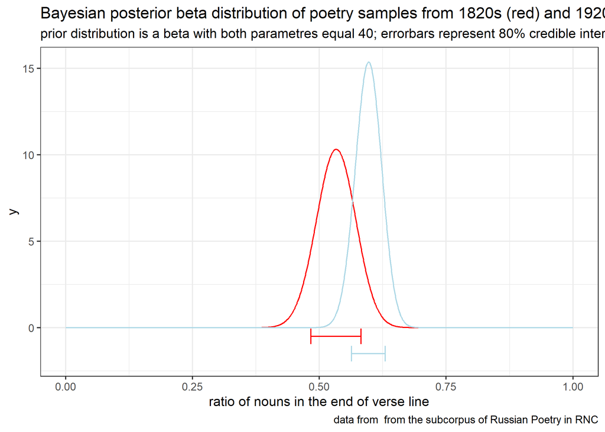

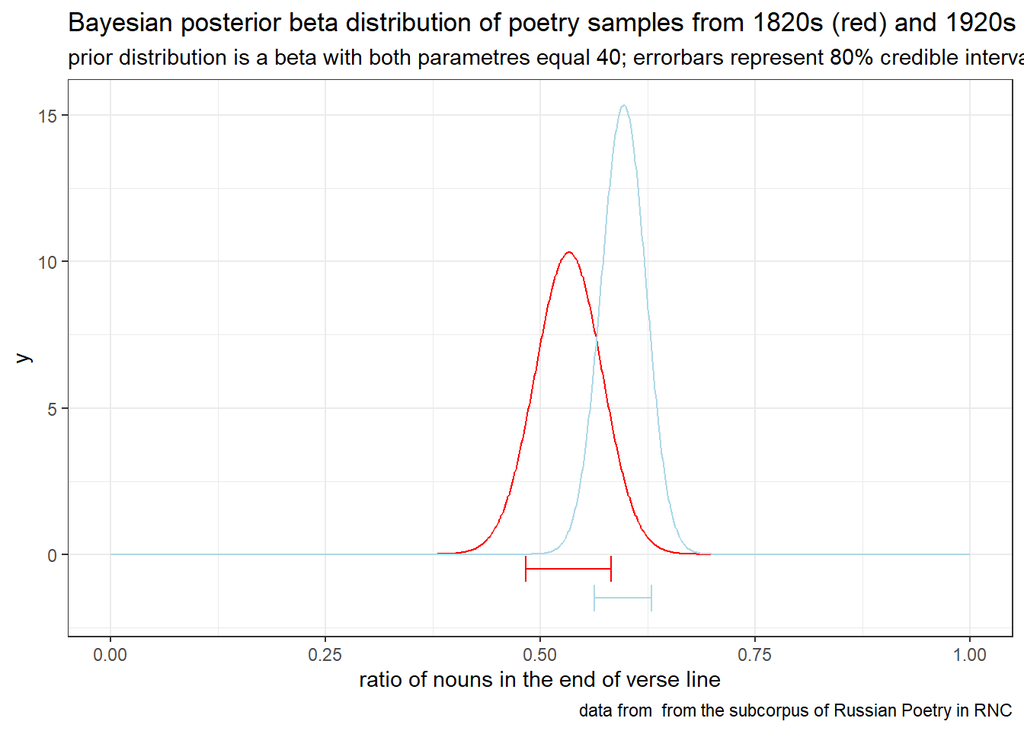

```r
df <- read_csv("RNC_verses.csv")

df %>%
  mutate(pos = ifelse(pos == "NOUN", "NOUN", "OTHER")) %>%
  count(decade, pos) %>%
  pivot_wider(names_from = pos, values_from = n) %>%
  mutate(post_a = NOUN + 40,
         post_b = OTHER + 40) ->
  res

ggplot()+
  stat_function(fun = dbeta, args = c(res$post_a[1], res$post_b[1]), color = "red", n = 1000)+
  stat_function(fun = dbeta, args = c(res$post_a[2], res$post_b[2]), color = "lightblue", n = 1000)+
  annotate(geom = "errorbar", y = -0.5,
           xmin = qbeta(0.1, res$post_a[1], res$post_b[1]),
           xmax = qbeta(0.9, res$post_a[1], res$post_b[1]), color = "red")+
  annotate(geom = "errorbar", y = -1.5,
            xmin = qbeta(0.1, res$post_a[2], res$post_b[2]),
           xmax = qbeta(0.9, res$post_a[2], res$post_b[2]), color = "lightblue")+
  xlim(0, 1)+
  labs(x = "ratio of nouns in the end of verse line",
       title = "Bayesian posterior beta distribution of poetry samples from 1820s (red) and 1920s (blue)",
       caption = "data from  from the subcorpus of Russian Poetry in RNC",
       subtitle = "prior distribution is a beta with both parametres equal 40; errorbars represent 80% credible intervals")
```

```r
ggsave("task_2.2.png")
```

## task 2.3 (вес задания: 2)

В датасет `eurasianphonology.csv` в вашем репозитории записаны агрегированные данные из базы данных фонологических систем Евразии http://eurasianphonology.info (Nikolaev et al. 2015). Смоделируйте распределение доли гласных из всех сегментов нормальным распределением с априорным нормальным распределением со средним = 0.301 и стандартным отклонением = 0.118, посчитайте 80% байесовский доверительный интервал и визуализируйте все это на графике (обратите внимание на подписи).

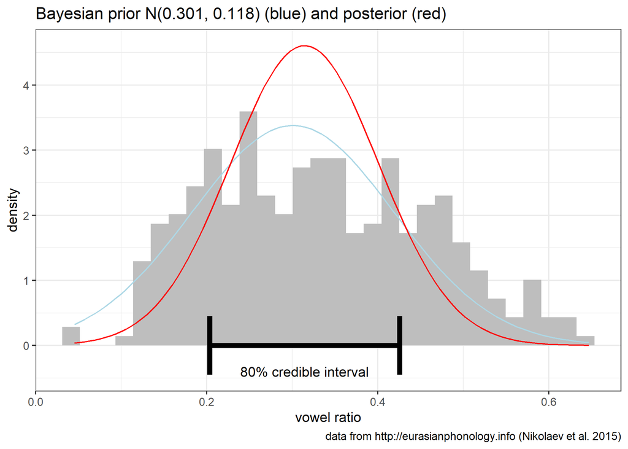

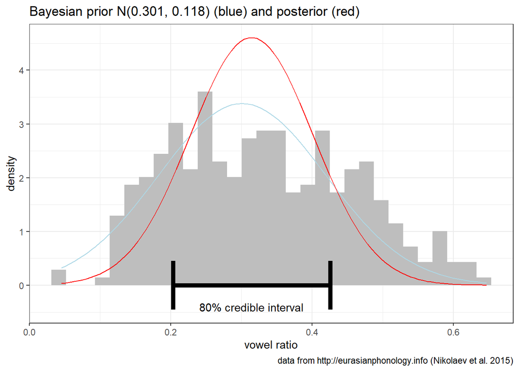

```r
read_csv("eurasianphonology.csv") %>%
  pivot_wider(names_from = segment_type, values_from = n) %>%
  mutate(ratio = vowel/(vowel+consonant)) ->
  res

sd_prior <- 0.118
sd_data <- sd(res$ratio)
sd_post <- 1/sqrt(1/sd_prior^2 + 1/sd_data^2)
mean_prior <- 0.301
mean_data <- mean(res$ratio)
mean_post <- weighted.mean(c(mean_prior, mean_data), c(1/sd_prior^2, 1/sd_data^2))

cred_int_l <- qnorm(0.1, mean_post, sd_post)
cred_int_h <- qnorm(0.9, mean_post, sd_post)

res %>%
  ggplot(aes(ratio)) +
  geom_histogram(aes(y = ..density..), fill = "grey")+
  stat_function(fun = dnorm, args = list(mean_prior,  sd_prior), color = "lightblue")+
  stat_function(fun = dnorm, args = list(mean_post,  sd_post), color = "red")+
  annotate(geom = "errorbar", y = 0, xmin = cred_int_l, xmax = cred_int_h, size = 2)+
  annotate(geom = "text", y = -0.4, x = mean_post, label = "80% credible interval")+
  labs(x = "vowel ratio",
       caption = "data from http://eurasianphonology.info (Nikolaev et al. 2015)",
       title = "Bayesian prior N(0.301, 0.118) (blue) and posterior (red)")
```

```r
ggsave("task_2.3.png")
```

## task 2.4 (вес задания: 1)

Приведите ниже аргумент(ы) за/против модели в задании 2.3.

- Доля $\in [0, 1]$, а нормальное распределение $\in [-\infty, +\infty]$, хотя и на невероятные значения остается лишь чуть больше одной десятитысячной:

```r
1 - integrate(dnorm, lower = 0, upper = 1, mean = mean_post, sd = sd_post)$value
```

```
## [1] 0.0001397938
```

- В данной модели мы предполагаем, что все наблюдения не зависят друг от друга, однако в действительности, в датасете представлены достаточно много родственных языков, таким образом в данных есть внутренние группировки, которые бы в идеале стоило бы учитывать.

## task 2.5 (вес задания: 3)

В датасет `vowel_data.csv` записаны значения формант гласных для носителей британского английского языка из исследования [Sönning, Lukas 2021]. Используя данные всех носителей, провидете эмпирическую байесовскую оценку, чтобы получить априорное распределение, сделайте байесовский апдейт всех носителей и постройте график 80% доверительных интервалов для каждого носителя. Какой носитель, согласно полученным доверительным интервалам, показывает самую невыразительную разницу между гласными?

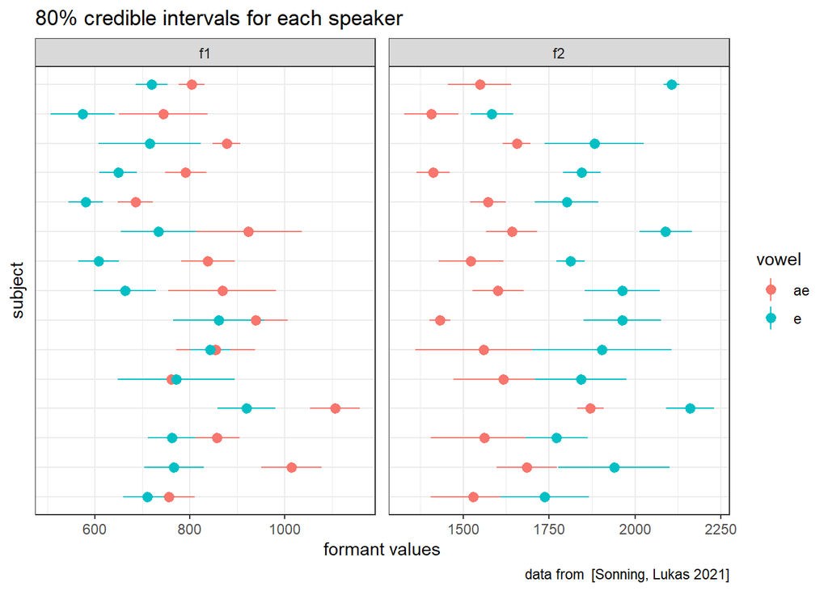

```r
br_vowels <- read_csv("vowel_data.csv")

br_vowels %>%
  filter(vowel == "e") %>%
  pull(F1) %>%
  fitdistrplus::fitdist(distr = 'norm', method = 'mle')->
  e_f1

br_vowels %>%
  filter(vowel == "e") %>%
  pull(F2) %>%
  fitdistrplus::fitdist(distr = 'norm', method = 'mle')->
  e_f2

br_vowels %>%
  filter(vowel == "ae") %>%
  pull(F1) %>%
  fitdistrplus::fitdist(distr = 'norm', method = 'mle')->
  ae_f1

br_vowels %>%
  filter(vowel == "ae") %>%
  pull(F2) %>%
  fitdistrplus::fitdist(distr = 'norm', method = 'mle')->
  ae_f2

e_f1$estimate %>%
  bind_rows(e_f2$estimate,
            ae_f1$estimate,
            ae_f2$estimate) %>%
  mutate(formant = c("f1", "f2", "f1", "f2"),
         vowel = c("e", "e", "ae", "ae")) %>%
  rename(mean_prior = mean,
         sd_prior = sd) ->
  priors

br_vowels %>%
  group_by(subject, vowel) %>%
  summarise(mean_f1 = mean(F1),
            mean_f2 = mean(F2),
            sd_f1 = sd(F1),
            sd_f2 = sd(F2)) %>%
  pivot_longer(names_to = "type", values_to = "values", mean_f1:sd_f2) %>%
  separate(type, into = c("type", "formant")) %>%
  pivot_wider(values_from = values, names_from = "type") %>%
  left_join(priors) %>%
  rowwise() %>%
  mutate(sd_post = 1/sqrt(1/sd_prior^2 + 1/sd^2),
         mean_post = weighted.mean(c(mean_prior, mean),
                                   c(1/sd_prior^2, 1/sd^2)),
         cred_int_l_80 = qnorm(0.1, mean_post, sd_post),
         cred_int_h_80 = qnorm(0.9, mean_post, sd_post),
         cred_int_mean = cred_int_h_80-(cred_int_h_80-cred_int_l_80)/2) %>%
  ggplot(aes(y = subject, x = cred_int_mean,
             xmin = cred_int_l_80, xmax = cred_int_h_80, color = vowel))+
  geom_pointrange()+
  facet_wrap(~formant, scales = "free")+
  theme(axis.text.y = element_blank(), # remove in order to see the answers
        axis.ticks.y = element_blank())+ # remove in order to see the answers
  labs(x = "formant values",
       title = "80% credible intervals for each speaker",
       caption  = "data from  [Sönning, Lukas 2021]")
```

```r
ggsave("english_vowels.png")
```

## task 2.6 (вес задания: 1)

Место для рефлексии по поводу ответов. Заполняется после того, как присланы ответы на задания до 12.03.2022 23:59. Это оцениваемое задание.